# Лабораторная работа № 1

Основы информационной безопасности

Казазаев Д. М.

Российский университет дружбы народов, Москва, Россия

# Информация

## Докладчик

- Казазаев Даниил Михайлович
- Студент бакалавриата
- Российский университет дружбы народов
- [1132231427@rudn.ru]
- https://github.com/KazazaevDaniil/study_2024-2025_infosec-intro

# Вводная часть

## Цели и задачи

Целью данной работы является приобретение практических навыков установки операционной системы на виртуальную машину, настройки минимально необходимых для дальнейшей работы сервисов.

## Материалы и методы

Для выполнения лабораторной работы мы воспользуемся виртуальной машиной Oracle VM Virtual Box. Лабораторные работы выполняется на домашнем оборудовании.

## Содержание исследования

- Этапы работы
- 1. Установка необходимого ПО и его настройка

# Выполнение лабораторной работы.

## Выполнение лабораторной работы.

Для начала откроем наше приложение, в котором у нас будет виртуальная машина. (рис. 1)

[figure not shown]

Открытый VirtualBox

## Выполнение лабораторной работы.

Перехожу к установке. Даю название и образ iso. (рис. 2)

[figure not shown]

Начало установки

## Выполнение лабораторной работы.

Устанавливаю имя пользователя и пароль.(рис. 3)

[figure not shown]

Установка имени пользователя и пароля

## Выполнение лабораторной работы.

Устанавливаю значения оборудования виртуальной машины(рис. 4)

[figure not shown]

Установка значений памяти и ЦП

## Выполнение лабораторной работы.

Выделяю необходимый объем памяти ЖД.(рис. 5)

[figure not shown]

Выделение объема памЯяти

## Выполнение лабораторной работы.

После всех приготовлений попадаю на главный экран начала установкит нашей ос.(рис. 6)

[figure not shown]

Начало внутренней настройуки ОС

## Выполнение лабораторной работы.

Доюавляю память нашей вирутальной ОС.(рис. 7)

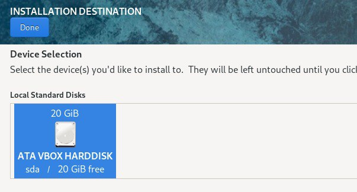

Добавление памяти

## Выполнение лабораторной работы.

Устанавливаю права администратора.(рис. 8)

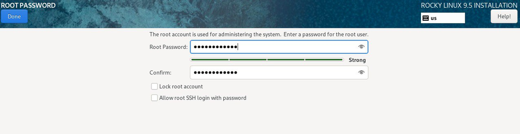

КУстановка прав администратора

## Выполнение лабораторной работы.

Установка ОС после ее настройки.(рис. 9)

[figure not shown]

Установка ОС

## Выполнение домашней работы.

Прописав необходимые команды нашел информацию о верисии Линукс, модели иоего ЦП и информацию о гипервизоре.(рис. 10)

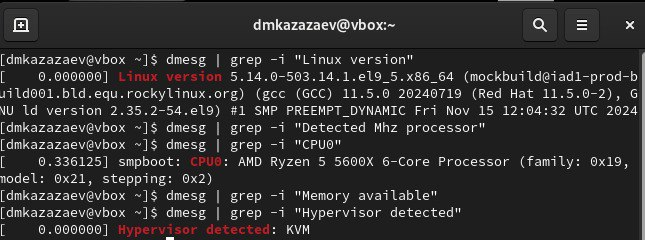

Найденная информация

## Выполнение домашней работы.

Чуть поискав информации и попрбовав разные записи, обнаружил, что остальные команды тоже можно выполнить

Ищу частоту процессора, которая составляет 3693 Mhz. (рис. 11)

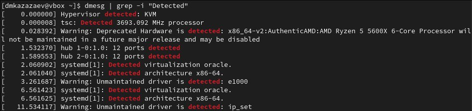

Cкорость процессора

## Выполнение домашней работы.

Ищу количество доступной памяти. (рис. 12)

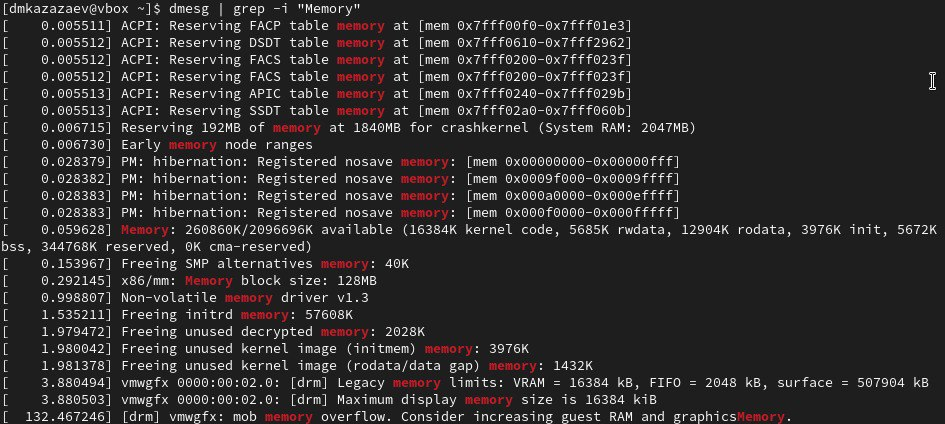

Информация о доступной памяти

## Выполнение домашней работы.

Ищу информацию о типе файловой системы. (рис. 13)

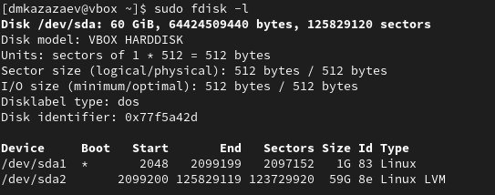

Про файловую систему

## Выполнение домашней работы.

Последней командой ищу последовательность монтирования файловых систем. (рис. 14)

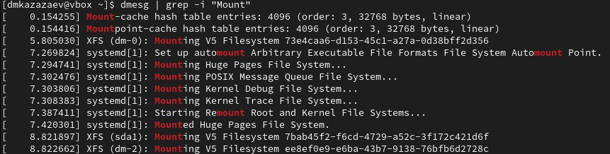

Про файловую систему

# Вывод

В результате выполнения данной лабораторной работы я вспомнил, как устанавливать операционную систему на виртуальную машину

## Результаты

- В ходе выполенения мы вспомнили, как устанавливать ОС на виртуальную машину